# DV_TProject1

## Analysis:

From this scatterplot, we can tell that except Police Department, Fire Department, Waste Water, Law Department are clustering and do not have a clear relationship between Annual Salary and Gross Salary, other roles in the following agencies, Circuit Court, City Council, Community Relations, Company Audits, Company Controllers/ Communications, DFW-Administration etc. all share a high positive correlation coefficient and can be accurately modeled with a linear model.

## Third Plot: This is a crosstab, and we are using Baltimore Salaries dataset to plot it.

[figure not shown]

## Analysis:

We find that if $40,000 and $67,510 are the parameters that determine “Low”, “Medium”, “High”, then very few poeple’s salaries fall in the range over $67,510, and the majority of salaries of Baltimore employees are categorized as “Low” and “Medium”.

## Fourth Plot: We filter the job title and only look at SUPERVISOR roles.

[figure not shown]

## Fifth Plot: This is a bar chart, and we are using Alaska Oil Well dataset to plot it.

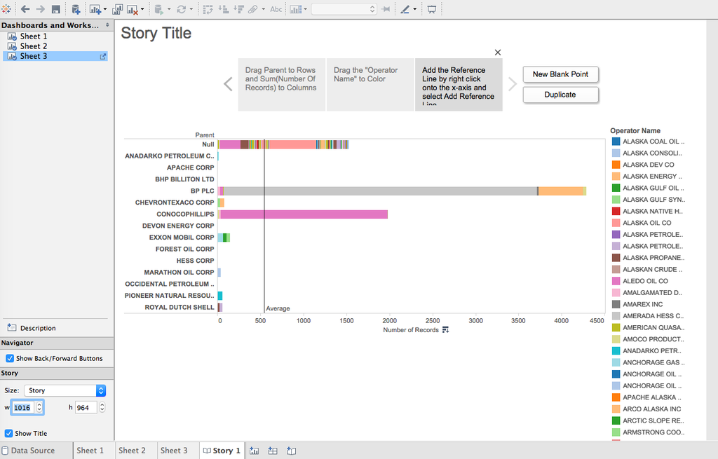

## Blending data using SQL and R

```r
source("../03 R SQL Visualizations/Blending_Texas&Baltimore_Hiredate.R", echo = TRUE)
```

```
##
## > require("jsonlite")
##
## > require("RCurl")
##
## > require("dplyr")
##
## > BALTIMORE_SALARY <- data.frame(fromJSON(getURL(URLencode("skipper.cs.utexas.edu:5001/rest/native/?query=\"select * from BALTIMORE_SALARY\""),
## +     .... [TRUNCATED]
##
## > TEXAS_SALARY <- data.frame(fromJSON(getURL(URLencode("skipper.cs.utexas.edu:5001/rest/native/?query=\"select * from TEXAS_SALARIES\""),
## +     httph .... [TRUNCATED]
##
## > df <- data.frame(dplyr::left_join(BALTIMORE_SALARY,
## +     TEXAS_SALARY, by = "SERIALID"))
##
## > head(df)
##               NAME.x                    JOBTITLE.x AGENCYID.x
## 1   Aaron,Patricia G Facilities/Office Services II     A03031
## 2      Aaron,Petra L     ASSISTANT STATES ATTORNEY     A29005
## 3 Abaineh,Yohannes T                EPIDEMIOLOGIST     A65026
## 4 Abdal-Rahim,Naim A               EMT Firefighter     A64063
## 5     Abdi,Ezekiel W                POLICE OFFICER     A99398
## 6   Abdul Hamid,Umar     LIQUOR BOARD INSPECTOR II     A09001
##                  AGENCY.x HIREDATE.x SERIALID ANNUALSALARY.x GROSSPAY.x
## 1      OED-Employment Dev   10/24/79        1          50845   45505.94
## 2 States Attorneys Office    9/25/06        2          56595   51588.89
## 3  HLTH-Health Department    7/23/09        3          56500   50633.26
## 4   Fire Academy Recruits    3/30/11        4          33476    3888.95
## 5       Police Department    6/14/07        5          50919   51421.73
## 6    Liquor License Board    1/17/95        6          43278   39116.93
##               NAME.y                    JOBTITLE.y AGENCYID.y
## 1   Aaron,Patricia G Facilities/Office Services II     A03031
## 2      Aaron,Petra L     ASSISTANT STATES ATTORNEY     A29005
## 3 Abaineh,Yohannes T                EPIDEMIOLOGIST     A65026
## 4 Abdal-Rahim,Naim A               EMT Firefighter     A64063
## 5     Abdi,Ezekiel W                POLICE OFFICER     A99398
## 6   Abdul Hamid,Umar     LIQUOR BOARD INSPECTOR II     A09001
##                  AGENCY.y HIREDATE.y ANNUALSALARY.y GROSSPAY.y
## 1      OED-Employment Dev   10/24/79          50845   45505.94
## 2 States Attorneys Office    9/25/06          56595   51588.89
## 3  HLTH-Health Department    7/23/09          56500   50633.26
## 4   Fire Academy Recruits    3/30/11          33476    3888.95
## 5       Police Department    6/14/07          50919   51421.73
## 6    Liquor License Board    1/17/95          43278   39116.93
##   ANNUAL_SALARY
## 1          null
## 2          null
## 3          null
## 4          null
## 5          null
## 6          null
```